# 兩個類別變數有沒有關聯？

方法比較：categorical-association Skill 用到的方法，差在哪裡

**提示這一頁要回答**

同樣是「兩個類別變數有沒有關聯」，碰到不同情況要用不同的方法。這一頁只講**它們差在哪裡**；例子都是假想資料，公式收在可以展開的框裡。

## 一張表看懂

| 你想知道 | 可以用的方法 | 差別在哪 | 例子（假想） |
| --- | --- | --- | --- |
| 兩組差多少？ | 比例差、相對風險、勝算比 | 比例差說「差幾個百分點」，相對風險說「機率是幾倍」，勝算比說「**勝算**是幾倍」 | 吃宵夜胃不舒服 24% vs 10%：差 14 個百分點、相對風險 2.40、勝算比 2.84 |
| 有沒有關聯？ | 卡方檢定、Fisher 精確檢定 | 卡方靠大樣本近似；樣本太小、期望次數太小時改用 Fisher | 8 杯手搖飲猜甜度：卡方 P = 0.157（不可靠），Fisher P = 0.486 |
| 變數有順序時？ | 卡方 vs 趨勢檢定 | 卡方忽略順序；趨勢檢定只看「越…越…」，證據集中、通常更有力，還能看出方向 | 滑手機越久睡越差嗎：卡方 df = 3，趨勢檢定 df = 1，P 值更小 |
| 有第三個變數時？ | 合併看 vs 分層看（CMH） | 合併的結果可能被第三個變數誤導，甚至方向相反；分層後才是控制後的結果 | 補習班：合併看 A 較好，分學生程度後兩群都是 B 較好 |

**警告共同前提：每一筆資料彼此獨立**

以上方法都假設**每一列是不同、互不相關的個體**。同一個人測兩次、前後測、同一個學生的兩科成績，都不符合，要改用配對資料的方法（組員 Part 3 的 Skill）。

```
flowchart LR
    A[兩個類別變數] --> B{每列獨立？}
    B -- 否 --> P3[配對／相關資料方法]
    B -- 是 --> C{要控制第三個變數？}
    C -- 是 --> S[分層分析＋CMH]
    C -- 否 --> D{有變數有順序？}
    D -- 是 --> T[趨勢檢定]
    D -- 否 --> E{期望次數夠大？}
    E -- 是 --> X[卡方檢定]
    E -- 否 --> F[Fisher 精確檢定]
```

## 1. 兩組差多少：比例差、相對風險、勝算比

例子：吃宵夜的人隔天胃不舒服的比例是 24%，沒吃的是 10%（各 200 人）。

| 方法 | 這個例子 | 怎麼說 |
| --- | --- | --- |
| 比例差 | 0.14 | 多了 14 個百分點 |
| 相對風險 | 2.40 | 比例是 2.40 倍 |
| 勝算比 | 2.84 | **勝算**是 2.84 倍，不是機率 2.84 倍 |

- 勝算比和相對風險只有在比例都很小時才接近。
- case-control 研究（先找病人和對照組，再回頭調查）只能報勝算比。

**注记公式（點開查看）**

$$\hat\pi_1 - \hat\pi_2, \qquad \frac{\hat\pi_1}{\hat\pi_2}, \qquad \hat\theta = \frac{\hat\pi_1/(1-\hat\pi_1)}{\hat\pi_2/(1-\hat\pi_2)} = \frac{n_{11}n_{22}}{n_{12}n_{21}}$$

## 2. 有沒有關聯：卡方 vs Fisher

例子：朋友說她喝得出手搖飲是不是無糖。8 杯裡（4 杯無糖、4 杯全糖）她猜對 6 杯。

| 方法 | P 值 | 說明 |
| --- | --- | --- |
| 卡方檢定 | 0.157 | 每格的期望次數只有 2，大樣本近似**可能不可靠** |
| Fisher 精確檢定 | 0.486 | 不需要大樣本，這種情況以它為主 |

兩個都 > 0.05：8 杯猜對 6 杯，證據還不足以說她喝得出來。

- 什麼時候算「期望次數太小」：2×2 表有一格 < 5；更大的表有一格 < 1，或超過 20% 的格子 < 5（Cochran 準則）。重點是表格稀不稀疏，不是總人數。

**注记公式與延伸：mid-P（點開查看）**

$$X^2 = \sum_{i,j}\frac{(n_{ij}-\hat\mu_{ij})^2}{\hat\mu_{ij}}, \qquad \hat\mu_{ij} = \frac{n_{i+}n_{+j}}{n}$$

Fisher 精確檢定固定行列總和，用超幾何分配算出「比觀察到的更極端」的機率。因為分配是離散的，小樣本時偏保守。**mid-P** 是一種替代做法，這個例子 mid-P = 0.257。Skill 第一版為了避免同時給好幾種 P 值，只報 Fisher；mid-P 留作之後的延伸。

## 3. 變數有順序：卡方 vs 趨勢檢定

例子：每天滑手機的時間（<1、1–3、3–5、>5 小時）越長，睡眠品質越差嗎？

| 方法 | 結果 | 差別 |
| --- | --- | --- |
| 卡方檢定 | X² = 17.35（df = 3） | 把四個時段當成沒有順序，只說「有關」 |
| 趨勢檢定 | M² = 17.27（df = 1） | 只檢定「越久越差」，證據集中在 1 個自由度，P 值更小，還告訴你方向 |

- 結果是二元、解釋變數有順序（像這個例子）叫 **Cochran–Armitage 趨勢檢定**；兩個都有順序叫 **linear-by-linear association 檢定**。
- 每個類別要給一個分數（這裡用各時段中點），類別間距不相等時，分數會影響結果。
- 名目變數（例如通勤方式）沒有順序，**不能**做趨勢檢定；數字代碼 1、2、3、4 也不代表有順序。

**注记公式（點開查看）**

以類別分數算出樣本相關係數 $r$：$M^2 = (n-1)r^2 \sim \chi^2_1$。

## 4. 有第三個變數：合併看 vs 分層看

例子：A、B 兩家補習班的考上率。合併來看 A 比較好，但分成「基礎好」「基礎差」兩群學生呢？

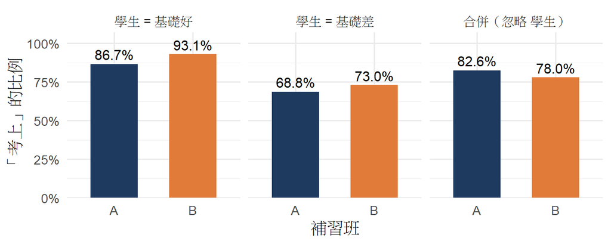

| 看法 | 勝算比（A 相對於 B） |
| --- | --- |
| 合併看 | 1.34（A 較好） |
| 基礎好的學生 | 0.48（B 較好） |
| 基礎差的學生 | 0.81（B 較好） |

- 這就是 **Simpson 悖論**：A 收的多是基礎好的學生，而基礎好的人本來就容易考上。
- 控制學生程度後用 **CMH 檢定**：P = 0.027，共同勝算比 0.69，B 的考上勝算較高。
- 分層前要先想清楚：學生程度同時影響選補習班和考上，是**干擾變數**，應該控制；如果是補習班造成的結果（中介變數），就不該控制。
- 各層方向不一致時，不能只報一個共同勝算比，要逐層報告。

**注记公式（點開查看）**

第 $k$ 層的條件勝算比 $\hat\theta_{XY(k)} = n_{11k}n_{22k}/(n_{12k}n_{21k})$。CMH 檢定的虛無假設是每一層 $\theta_{XY(k)} = 1$（控制第三個變數後沒有關聯）。

## 重點整理

**提示選方法的口訣**

1. **先問獨立**：同一人多筆、配對 → 不用這頁的方法
2. **再問順序**：有順序 → 趨勢檢定比卡方有力
3. **看期望次數**：太小 → Fisher
4. **想控制別的變數**：先確認是干擾變數 → 分層＋CMH，留意 Simpson 悖論
5. **報關聯大小**：P 值只說有沒有證據，比例差、相對風險、勝算比才說多大

## 參考文獻

Agresti, A. (2019). *An Introduction to Categorical Data Analysis* (3rd ed.). Wiley.

Fisher, R. A. (1935). *The Design of Experiments*. Oliver & Boyd.

本頁所有例子的數字都是假想資料，只用來說明方法的差別。